# Laluz - porównanie żarówek

Beata Łozowska, Filip Kąkol

2025-01-08

#### Autorzy:

- 444808 | Beata Łozowska | b.lozowska3@student.uw.edu.pl
- 413322 | Filip Kąkol | f.kakol@student.uw.edu.pl

## **Dane**

#### Przygotowanie danych

Dane otrzymaliśmy w formie pliku csv. W pierwszej kolejności należało wgrać plik do projektu:

```r
file_path <- "https://mimuw.edu.pl/~szym/laluz.csv"

data <- read.csv(file_path, sep = ";")
data <- data[, -5]
data <- na.omit(data)
head(data)
```

```
##   time_in_hours price_in_PLN product_type sprayed
## 1        3637.8         9.90 regular bulb    none
## 2        2684.3        10.00 regular bulb    none
## 3        3677.9         9.99 regular bulb    none
## 4        3643.5        10.00 regular bulb    none
## 5        3128.8         9.95 regular bulb    none
## 6        1956.0         9.90 regular bulb    none
```

#### Krótkie wytłumaczenie:

- w zmiennej `file_path` przechowywana jest ścieżka do pliku
- ważne jest ustawienie separatora podczas odczytu pliku na średnik korzystając z argumentu `sep = ";"`
- dane z pliku przypisaliśmy do zmiennej `data`
- `data <- data[, -5]`usuwamy nieistotną kolumnę “manufacture_plant” w której znajdują dane dotyczące fabryk w których zostały wyprodukowane żarówki
- `data <- na.omit(data)` - usuwamy wszystkie wiersze w których są puste wartości. Usunięto tylko ostatni wiersz zaiwerający cenę sprayu

#### Charakterystyka danych

Korzystając z poniższych funkcji pomocniczych przygotowaliśmy krótki wgląd do podstawowych informacji o danych (w komentarzach znajdują się detaliczne informacje o każdej funkcji)

```r
dim(data) # zlicza wiersze i kolumny
```

```
## [1] 400   4
```

```r
colnames(data) # listuje nagłówki kolumn
```

```
## [1] "time_in_hours" "price_in_PLN"  "product_type"  "sprayed"
```

```r
summary(data) # podsumowanie głównych statystyk kolumn
```

```
##  time_in_hours    price_in_PLN   product_type         sprayed
##  Min.   : 1223   Min.   : 9.00   Length:400         Length:400
##  1st Qu.: 2702   1st Qu.: 9.99   Class :character   Class :character
##  Median : 3348   Median :14.53   Mode  :character   Mode  :character
##  Mean   : 3736   Mean   :14.96
##  3rd Qu.: 4308   3rd Qu.:19.99
##  Max.   :31870   Max.   :20.10
```

```r
unique(data$product_type) # unikalne wartości w kolumnie product_type
```

```
## [1] "regular bulb" "DoubleBulb"
```

```r
unique(data$sprayed) # unikalne wartości w kolumnie sprayed
```

```
## [1] "none"           "CoatItYourself"
```

#### Poniższy wykres przedstawia dane wykorzystane do przeprowadzenia badania:

```r
bulb_labels <- c("Żarówka podwójna", "Żarówka pojedyncza")
bulb_color <- c("#63C13270", "#FF000070")


if (!requireNamespace("ggplot2")) {
  install.packages("ggplot2")
}
```

```
## Ładowanie wymaganej przestrzeni nazw: ggplot2
```

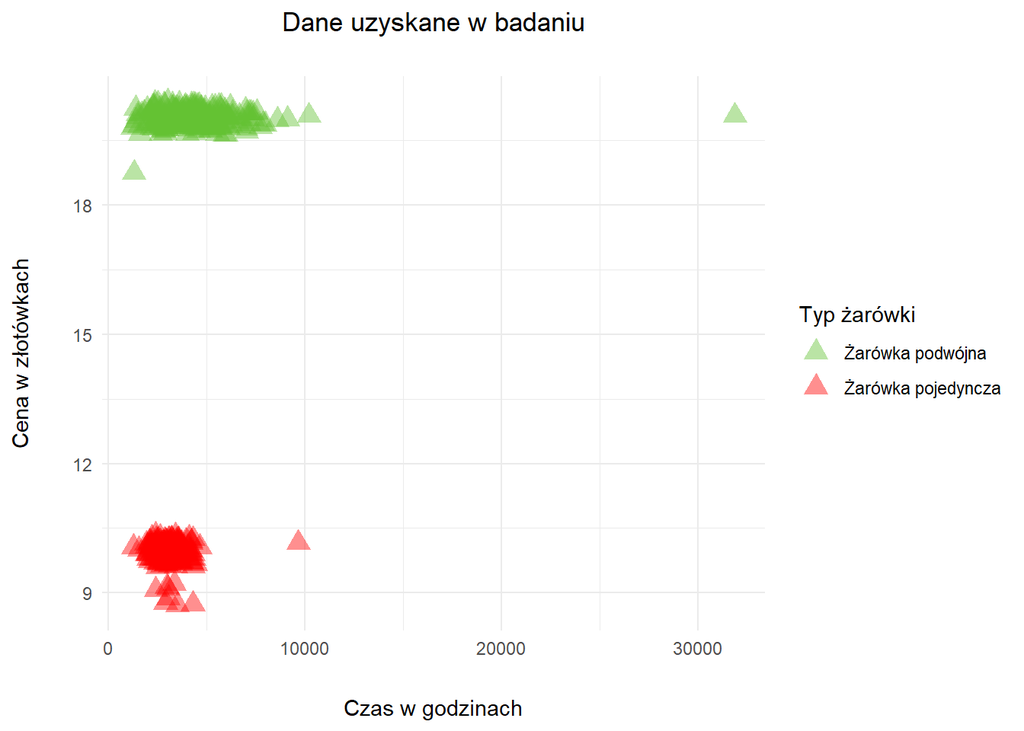

```r
library(ggplot2) #Wczytanie pakietu ggplot2
ggplot(data, aes(x = time_in_hours, y = price_in_PLN, color = product_type, shape = product_type)) +
  geom_point(size = 4, position = position_jitter(width = 0.3, height = 0.3)) +  # Dodanie scatter
  scale_color_manual(values = bulb_color, name = "Typ żarówki", labels = bulb_labels) +
  scale_shape_manual(values = c("DoubleBulb" = 17, "regular bulb" = 17), name = "Typ żarówki", labels = bulb_labels) +
  labs(
    x = "Czas w godzinach",
    y = "Cena w złotówkach",
    title = "Dane uzyskane w badaniu"
  ) +
  theme_minimal() +
  theme(
    plot.title = element_text(margin = margin(b = 20), hjust = 0.5),
    axis.title.x = element_text(margin = margin(t = 20)),
    axis.title.y = element_text(margin = margin(r = 20)),
  )
```

Na wykresie zauważyliśmy odstające dane, więc postanowiliśmy je zbadać.

#### Analiza danych odstających

Do identyfikacji wartości odstających wykorzystano wskaźnik z-score, który określa, jak bardzo dana wartość odbiega od średniej, wyrażając tę różnicę w jednostkach odchylenia standardowego. Wartości uznano za odstające, jeśli ich z-score przekracza 3 jednostki w górę lub w dół od zera. Użyte funkcje operują na ramce danych „dane” i zwracają indeksy wierszy, które zawierają takie odstające wartości.

```r
z_score_time_in_hours <- scale(data$time_in_hours)
outlier_time_in_hours <- which(abs(z_score_time_in_hours) > 3)

z_score_price_in_pln <- scale(data$price_in_PLN)
outlier_price_in_pln <- which(abs(z_score_price_in_pln) > 3)

print(outlier_time_in_hours) # zwrócono 288 373
```

```
## [1] 288 373
```

```r
print(outlier_price_in_pln) # zwrócono pusty wynik
```

```
## integer(0)
```

Przyjęto, że wartości odstające znajdują się w wierszach: 288 (31869.6 h), 373 (10199.5 h)

Są to wartości znacząco odbiegające od normy czasu działania żarówek, więc podjęlismy decyzję o usunięciu tych danych.

Podjęto decyzję o usunięciu danych, ponieważ uważamy że dane zostały źle wprowadzone - żarówka nie może świecić tak długo.

```r
outliner_data <- c(outlier_time_in_hours, outlier_price_in_pln)
data <- subset(data, !(1:nrow(data) %in% outliner_data))
```

## **Badanie**

### **Test 1 - Czy rzeczywiście żarówki o podwójnej bańce mają dłuższy średni czas życia niż żarówki o pojedynczej bańce?**

W pierwszej kolejności obliczyliśmy średni czas życia żarówki o pojedynczej bańce bez spraya oraz żarówki o podwójnej bańce bez spraya.

```r
# W pierszej kolejności należało wyfiltrować odpowiednio dane na potrzeby testu
# Pierwsza zmienna przechowuje dane żarówek regularnych bez użytego spraya
# Druga zmienna przechowuje dane żarówek double bez użytego spraya

regular_bulb_without_spray_filtered_data <- subset(data, product_type == "regular bulb" & sprayed == "none")
doubled_bulb_without_spray_filtered_data <- subset(data, product_type == "DoubleBulb" & sprayed == "none")

regular_bulb_without_spray_mean_time <- mean(regular_bulb_without_spray_filtered_data$time_in_hours, na.rm = TRUE) #na.rm = TRUE - usuwa puste wartości
doubled_bulb_without_spray_mean_time <- mean(doubled_bulb_without_spray_filtered_data$time_in_hours, na.rm = TRUE)
print(regular_bulb_without_spray_mean_time)
```

```
## [1] 2893.598
```

```r
print(doubled_bulb_without_spray_mean_time)
```

```
## [1] 4188.84
```

#### Poniższy wykres, przedstawia średni czas działania żarówek bez sprayu:

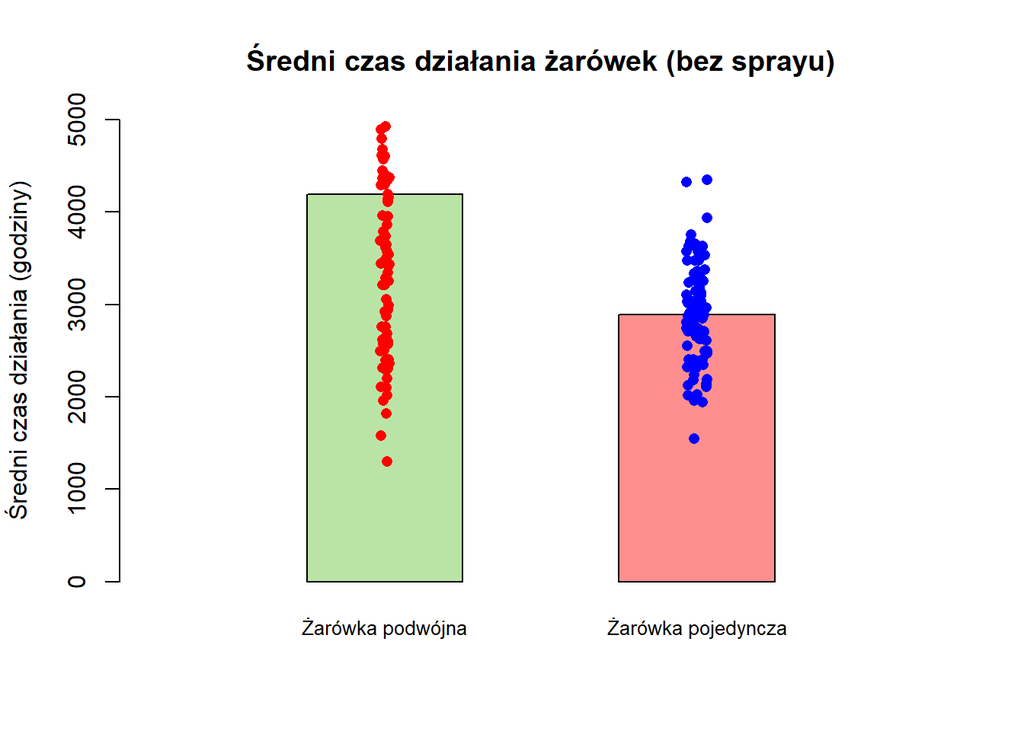

```r
mean_times <- c(doubled_bulb_without_spray_mean_time, regular_bulb_without_spray_mean_time)

# Tworzenie wykresu słupkowego
bar_positions <- barplot(
  mean_times,
  names.arg = bulb_labels,
  col = bulb_color,
  main = "Średni czas działania żarówek (bez sprayu)",
  xlab = "",
  ylab = "Średni czas działania (godziny)",
  xlim = c(0, 5), # Ustawienie zakresu os X
  ylim = c(0, 5000), # Ustawienie zakresu osi Y do 5000
  space = 1,  # Zmniejszenie szerokości słupków (odstęp pomiędzy słupkami)
  cex.names = 0.8
)

# Dodanie punktów dla regular_bulb
points(
  jitter(rep(bar_positions[1], length(doubled_bulb_without_spray_filtered_data$time_in_hour))), # Jitter dla losowego rozrzutu
  doubled_bulb_without_spray_filtered_data$time_in_hour,
  col = "red",
  pch = 16
)

# Dodanie punktów dla doubled_bulb
points(
  jitter(rep(bar_positions[2], length(regular_bulb_without_spray_filtered_data$time_in_hour))), # Jitter dla losowego rozrzutu
  regular_bulb_without_spray_filtered_data$time_in_hour,
  col = "blue",
  pch = 16
)
```

W związku z tym, że średnia czasu świecenia żarówki z podwójną bańką jest większa niż z pojedynczą, zdecydowaliśy zbadać, czy ta różnica jest istotna statystycznie.

Aby wybrać odpowiedni test statystyczny do odpowiedzi na ww. pytanie należało sprawdzić czy próby danych posiadają rozkład normalny, aby to sprawdzić użyliśmy testu Shapiro-Wilka.

#### Hipotezy

- **hipoteza zerowa - Dane pochodzą z rozkładu normalnego**
- **hipoteza alternatywna - Dane nie pochodzą z rozkładu normalnego**

#### Wykonanie

```r
# Następnie wykonaliśmy testy
shapiro_test_regular_bulb_without_spray <- shapiro.test(regular_bulb_without_spray_filtered_data$time_in_hours)
shapiro_test_doubled_bulb_without_spray <- shapiro.test(doubled_bulb_without_spray_filtered_data$time_in_hours)

print(shapiro_test_regular_bulb_without_spray)
```

```
##
##  Shapiro-Wilk normality test
##
## data:  regular_bulb_without_spray_filtered_data$time_in_hours
## W = 0.98958, p-value = 0.6303
```

```r
print(shapiro_test_doubled_bulb_without_spray)
```

```
##
##  Shapiro-Wilk normality test
##
## data:  doubled_bulb_without_spray_filtered_data$time_in_hours
## W = 0.95478, p-value = 0.001854
```

#### Wniosek

Zgodnie z otrzymanymi danymi, dla żarówek o pojedynczej bańce nie można odrzucić hipotezy zerowej. Dla żarówek z podwójną bańką odrzucamy hipotezę zerową, co oznacza że dane nie mają rozkładu normalnego.

Jeżeli jeden zestaw danych nie można uznać za zgodnych z rozkładem normalnym, musimy do dalszej analizy należy rozważyć metody niewymagające normalności. W naszym przypadku będzie to test Wilcoxa

#### Hipotezy

- **hipoteza zerowa - Żarówki o podwójnej bańce nie mają dłuższego średniego czasu życia niż żarówki o pojedynczej bańce.**
- **hipoteza alternatywna - Żarówki o podwójnej bańce mają dłuższy średni czas życia niż żarówki o pojedynczej bańce.**

```r
wilcox_regular_bulb_without_spray <- wilcox.test(
  doubled_bulb_without_spray_filtered_data$time_in_hours,
  regular_bulb_without_spray_filtered_data$time_in_hours,
  alternative = "greater"
)

# Wyświetlanie wyników testu
print(wilcox_regular_bulb_without_spray)
```

```
##
##  Wilcoxon rank sum test with continuity correction
##
## data:  doubled_bulb_without_spray_filtered_data$time_in_hours and regular_bulb_without_spray_filtered_data$time_in_hours
## W = 7267, p-value = 5.892e-09
## alternative hypothesis: true location shift is greater than 0
```

#### Wniosek

Bardzo niska wartość p-value wskazuje, że odrzucamy hipotezę zerową i wybieramy hipotezę alternatywną, która mówi że żarówki o podwójnej bańce mają dłuższy średni czas życia niż żarówki o pojedynczej bańce i jest to istotne statystycznie.

#### **Podsumowanie:**

**Żarówki o podwójnej bańce mają dłuższy średni czas działania niż żarówki o pojedynczej bańce.**

### **Test 2 - Czy rzeczywiście spray przedłuża średni czas życia żarówki? Obu typów?**

Na początku obliczyliśmy średni czas działania żarówki z podwójną bańką z użyciem spraya oraz z pojedynczą bańką z użyciem spraya i porównaliśmy je z wynikami dla tych samych żarówek ale bez użycia dodatkowego sprayu.

```r
regular_bulb_with_spray_filtered_data <- subset(data, product_type == "regular bulb" & sprayed == "CoatItYourself")
doubled_bulb_with_spray_filtered_data <- subset(data, product_type == "DoubleBulb" & sprayed == "CoatItYourself")

regular_bulb_with_spray_mean_time <- mean(regular_bulb_with_spray_filtered_data$time_in_hours, na.rm = TRUE) #na.rm = TRUE - usuwa puste wartości
doubled_bulb_with_spray_mean_time <- mean(doubled_bulb_with_spray_filtered_data$time_in_hours, na.rm = TRUE)

# średnia czasu dla żarówki regularnej ze sprayem
print(regular_bulb_with_spray_mean_time)
```

```
## [1] 3260.59
```

```r
# średnia czasu dla żarówki regularnej bez spraya
print(regular_bulb_without_spray_mean_time)
```

```
## [1] 2893.598
```

```r
# średnia czasu dla żarówki podwójnej ze sprayem
print(doubled_bulb_with_spray_mean_time)
```

```
## [1] 4266.477
```

```r
# średnia czasu dla żarówki podwójnej bez spraya
print(doubled_bulb_without_spray_mean_time)
```

```
## [1] 4188.84
```

Zauważyliśmy, że w obu przypadkach średnia czasu działania żarówki ze sprayem jest większa niż w żarówkach bez sprayu, więc zdecydowaliśmy, że sprawdzimy czy te różnice są statystycznie istotne.

Aby wybrać odpowiedni test statystyczny do odpowiedzi na ww. pytanie należało sprawdzić czy próby danych posiadają rozkład normalny, aby to sprawdzić użyliśmy testu Shapiro-Wilka.

##### Hipotezy

- **hipoteza zerowa - Dane pochodzą z rozkładu normalnego**
- **hipoteza alternatywna - Dane nie pochodzą z rozkładu normalnego**

##### Badanie rozkładu normalnego danych

```r
shapiro_test_regular_bulb_with_spray <- shapiro.test(regular_bulb_with_spray_filtered_data$time_in_hours)
shapiro_test_doubled_bulb_with_spray <- shapiro.test(doubled_bulb_with_spray_filtered_data$time_in_hours)
print(shapiro_test_regular_bulb_with_spray)
```

```
##
##  Shapiro-Wilk normality test
##
## data:  regular_bulb_with_spray_filtered_data$time_in_hours
## W = 0.77657, p-value = 5.019e-11
```

```r
print(shapiro_test_doubled_bulb_with_spray)
```

```
##
##  Shapiro-Wilk normality test
##
## data:  doubled_bulb_with_spray_filtered_data$time_in_hours
## W = 0.98807, p-value = 0.5207
```

```r
print(shapiro_test_regular_bulb_without_spray)
```

```
##
##  Shapiro-Wilk normality test
##
## data:  regular_bulb_without_spray_filtered_data$time_in_hours
## W = 0.98958, p-value = 0.6303
```

```r
print(shapiro_test_doubled_bulb_without_spray)
```

```
##
##  Shapiro-Wilk normality test
##
## data:  doubled_bulb_without_spray_filtered_data$time_in_hours
## W = 0.95478, p-value = 0.001854
```

##### Wniosek:

Ponieważ dane nie mają rozkładu normalnego (tj. p-value grup: żarówki z pojedynczą bańką ze sprayem oraz żarówki z podwójną bańką są mniejsze niż wartość 0.05) do dalszej analizy wykorzystaliśmy test wilcoxa, który porównuje mediany oby zbiorów.

#### Żarówka z pojedynczą bańką

##### Hipotezy:

- **hipoteza zerowa - Spray nie ma wpływu na średni czas życia żarówki z pojedynczą bańką**
- **hipoteza alternatywna - Spray ma wpływ na średni czas życia żarówki z pojedynczą bańką**

##### Badanie:

```r
wilcox_regular_bulb <- wilcox.test(regular_bulb_with_spray_filtered_data$time_in_hours, regular_bulb_without_spray_filtered_data$time_in_hours, alternative = "greater")
print(wilcox_regular_bulb)
```

```
##
##  Wilcoxon rank sum test with continuity correction
##
## data:  regular_bulb_with_spray_filtered_data$time_in_hours and regular_bulb_without_spray_filtered_data$time_in_hours
## W = 6440, p-value = 0.000218
## alternative hypothesis: true location shift is greater than 0
```

##### Wniosek:

W związku z tym, że p-value jest mniejsze niż 0.05 to przyjmujemy hipotezę alternatywną, że spray ma wpływ na czas życia żarówki z pojedynczą bańką.

#### Żarówka z podwójną bańką

##### Hipotezy:

- **hipoteza zerowa - Spray nie ma wpływu na średni czas życia żarówki z podwójną bańką**
- **hipoteza alternatywna - Spray ma wpływ na średni czas życia żarówki z podwójną bańką**

##### Badanie:

```r
wilcox_doubled_bulb <- wilcox.test(doubled_bulb_with_spray_filtered_data$time_in_hours, doubled_bulb_without_spray_filtered_data$time_in_hours, alternative = "greater")
print(wilcox_doubled_bulb)
```

```
##
##  Wilcoxon rank sum test with continuity correction
##
## data:  doubled_bulb_with_spray_filtered_data$time_in_hours and doubled_bulb_without_spray_filtered_data$time_in_hours
## W = 5189.5, p-value = 0.2371
## alternative hypothesis: true location shift is greater than 0
```

##### Wniosek:

W związku z tym, że p-value jest większe niż 0.05 to przyjmujemy hipotezę zerową, że spray nie ma wpływu na czas życia żarówki z podwójną bańką.

#### Podsumowanie:

**Spray ma wpływ jedynie na żarówki z pojedynczą bańką.**

### **Test 3 - Czy używanie którejś z tych alternatyw do zwykłych żarówek o pojedynczej bańce ma sens ekonomiczny?**

Aby odpowiedzieć na to pytanie obliczyliśmy następujące wartości:

#### Koszt jednego psiknięcia

```r
bulbs_with_spray <- subset(data, sprayed == "CoatItYourself")

total_time_spray <- sum(bulbs_with_spray$time_in_hours, na.rm = TRUE)

spray_price <- 100; # cena sprayu

one_shot_spray_price <- spray_price / total_time_spray;

print(one_shot_spray_price)
```

```
## [1] 0.0001336112
```

#### Koszt jednej godziny pracy żarówki

Aby obliczyć koszt jednej godziny pracy żarówki należy: - obliczyć średni czas działania danej żarówki - obliczyć średnią kwotę jaką trzeba zapłacić za daną żarówkę - podzielić średnią kwotę przez średni czas

##### Żarówka z pojedynczą bańką bez sprayu

```r
mean_time_regular_bulb_without_spray <- mean(regular_bulb_without_spray_filtered_data$time_in_hours)
mean_price_regular_bulb_without_spray <- mean(regular_bulb_without_spray_filtered_data$price_in_PLN)
price_per_hour_regular_bulb_without_spray <- mean_price_regular_bulb_without_spray / mean_time_regular_bulb_without_spray;
print(price_per_hour_regular_bulb_without_spray)
```

```
## [1] 0.003442773
```

##### Żarówka z pojedynczą bańką z użyciem sprayu

```r
mean_time_regular_bulb_with_spray <- mean(regular_bulb_with_spray_filtered_data$time_in_hours)
mean_price_regular_bulb_with_spray <- mean(regular_bulb_with_spray_filtered_data$price_in_PLN)
price_per_hour_regular_bulb_with_spray <- mean_price_regular_bulb_with_spray / mean_time_regular_bulb_with_spray + one_shot_spray_price;
print(price_per_hour_regular_bulb_with_spray)
```

```
## [1] 0.003173214
```

##### Żarówka z podwójną bańką bez sprayu

```r
mean_time_doubled_bulb_without_spray <- mean(doubled_bulb_without_spray_filtered_data$time_in_hours)
mean_price_doubled_bulb_without_spray <- mean(doubled_bulb_without_spray_filtered_data$price_in_PLN)
price_per_hour_doubled_bulb_without_spray <- mean_price_doubled_bulb_without_spray / mean_time_doubled_bulb_without_spray;
print(price_per_hour_doubled_bulb_without_spray)
```

```
## [1] 0.004774398
```

##### Żarówka z podwójną bańką z użyciem sprayu

```r
mean_time_doubled_bulb_with_spray <- mean(doubled_bulb_with_spray_filtered_data$time_in_hours)
mean_price_doubled_bulb_with_spray <- mean(doubled_bulb_with_spray_filtered_data$price_in_PLN)
price_per_hour_doubled_bulb_with_spray <- mean_price_doubled_bulb_with_spray / mean_time_doubled_bulb_with_spray + one_shot_spray_price;
print(price_per_hour_doubled_bulb_with_spray)
```

```
## [1] 0.004817745
```

[figure not shown]

```r
# Dane do wykresu
bulb_types <- c("Pojedyńcza żarówka bez sprayu", "Pojedyńcza żarówka ze sprayem", "Podwójna żarówka bez sprayu", "Podwójna żarówka ze sprayem")

price_per_hour <- c(
  price_per_hour_regular_bulb_without_spray * 100, # Zamiana na grosze
  price_per_hour_regular_bulb_with_spray * 100,
  price_per_hour_doubled_bulb_without_spray * 100,
  price_per_hour_doubled_bulb_with_spray * 100
)

bar_colors <- c("#63C132", "#63C13270", "#FF0000", "#FF000070")

# Tworzenie wykresu słupkowego
bar_positions <- barplot(
  price_per_hour,
  names.arg = bulb_types,
  col = bar_colors,
  main = "Koszt użytkowania żarówek (złotówki za godzinę)",
  xlab = "",
  ylab = "Cena za godzinę w zł",
  ylim = c(0, ceiling(max(price_per_hour) / 10) * 10 / 10), # Górna granica osi Y dopasowana do odstępów 0.1
  cex.names = 0.5,
  las = 1, # Obrót etykiet na osi X
  font.lab = 3 # Pochylona czcionka
)

# Dodanie wartości na słupkach (zaokrąglenie do  miejsc po przecinku)
text(
  x = bar_positions,
  y = price_per_hour,
  labels = round(price_per_hour, 3 ), # Wyświetlenie wartości z 2 miejscami po przecinku
  pos = 3, # Pozycja nad słupkami
  cex = 0.8, # Rozmiar tekstu
  col = "black"
)
```

Podwójne żarówki, zarówno ze sprayem (0.482 groszy), jak i bez sprayu (0.477 groszy), mają znacząco wyższy koszt użytkowania na godzinę w porównaniu do pojedynczych żarówek. Różnica ta wynosi około 50% w stosunku do najtańszej opcji.

#### Długość życia żarówki w latach

Aby obliczyć długość życia żarówki w latach należy: - obliczyć średni czas działania danej żarówki - podzielić średni czas działania żarówki przez liczbę godzin dziennego świecenia, aby uzyskać liczbę dni przez które świeci żarówkia - podzielić wyżej wyliczoną liczbę dni przez liczbę dni w roku, aby uzyskać ten czas w latach

Założyliśmy, że typowy użytkowik korzysta z żarówki 4h dziennie przez 365 dni w roku. Przypisaliśmy te wartości do poniższych zmiennych:

```r
light_hours_per_day <- 4; # zakładamy że żarówka działa przez 4 godziny dziennie
day_number_in_year <- 365; # ilość dni w roku (bez lat przystępnych)
```

##### Żarówka z pojedynczą bańką bez sprayu

```r
mean_time_regular_bulb_without_spray <- mean(regular_bulb_without_spray_filtered_data$time_in_hours);
regular_bulb_without_spray_day_count <- mean_time_regular_bulb_without_spray / light_hours_per_day;
regular_bulb_without_spray_year_count <- regular_bulb_without_spray_day_count / day_number_in_year;
print(regular_bulb_without_spray_year_count)
```

```
## [1] 1.981916
```

**Żywotnośc żarówki z pojedynczą bańką bez sprayu wynosi 1,98 lat**

##### Żarówka z pojedynczą bańką z użyciem sprayu

```r
mean_time_regular_bulb_with_spray <- mean(regular_bulb_with_spray_filtered_data$time_in_hours);
regular_bulb_with_spray_day_count <- mean_time_regular_bulb_with_spray / light_hours_per_day;
regular_bulb_with_spray_year_count <- regular_bulb_with_spray_day_count / day_number_in_year;
print(regular_bulb_with_spray_year_count)
```

```
## [1] 2.233281
```

**Żywotnośc żarówki z pojedynczą bańką z użyciem sprayu wynosi 2,23 lata**

##### Żarówka z podwójną bańką bez sprayu

```r
mean_time_doubled_bulb_without_spray <- mean(doubled_bulb_without_spray_filtered_data$time_in_hours);
doubled_bulb_without_spray_day_count <- mean_time_doubled_bulb_without_spray / light_hours_per_day;
doubled_bulb_without_spray_year_count <- doubled_bulb_without_spray_day_count / day_number_in_year;
print(doubled_bulb_without_spray_year_count)
```

```
## [1] 2.869069
```

**Żywotnośc żarówki z podwójną bańką bez sprayu wynosi 2,87 lat**

##### Żarówka z podwójną bańką z użyciem sprayu

```r
mean_time_doubled_bulb_with_spray <- mean(doubled_bulb_with_spray_filtered_data$time_in_hours);
doubled_bulb_with_spray_day_count <- mean_time_doubled_bulb_with_spray / light_hours_per_day;
doubled_bulb_with_spray_year_count <- doubled_bulb_with_spray_day_count / day_number_in_year;
print(doubled_bulb_with_spray_year_count)
```

```
## [1] 2.922244
```

**Żywotnośc żarówki z podwójną bańką z użyciem sprayu wynosi 2,92 lata**

#### Wykres - Długość życia żarówki w latach

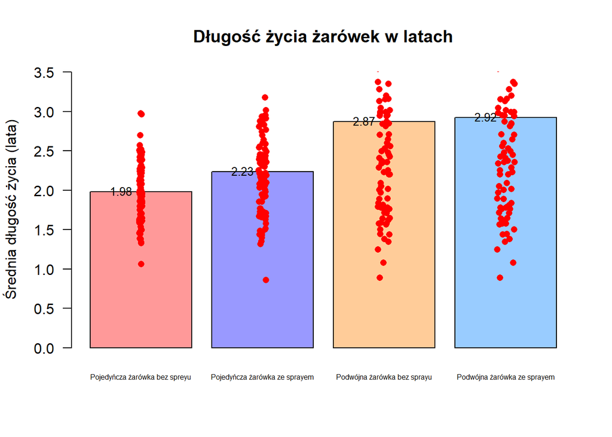

```r
# Wartości średniej długości życia w latach
life_years <- c(
  regular_bulb_without_spray_year_count,  # Żarówka pojedyncza bez sprayu
  regular_bulb_with_spray_year_count,    # Żarówka pojedyncza z użyciem sprayu
  doubled_bulb_without_spray_year_count, # Żarówka podwójna bez sprayu
  doubled_bulb_with_spray_year_count     # Żarówka podwójna z użyciem sprayu
)

# Etykiety
bulb_labels <- c(
  "Pojedyńcza żarówka bez spreyu",
  "Pojedyńcza żarówka ze sprayem",
  "Podwójna żarówka bez sprayu",
  "Podwójna żarówka ze sprayem"
)

# Kolory
bulb_colors <- c("#FF9999", "#9999FF", "#FFCC99", "#99CCFF")

# Wykres słupkowy
time_barplot <- barplot(
  height = life_years,
  names.arg = bulb_labels,
  col = bulb_colors,
  main = "Długość życia żarówek w latach",
  xlab = "",
  ylab = "Średnia długość życia (lata)",
  ylim = c(0, max(life_years) * 1.2),
  las = 1,     # Pochylenie etykiet osi X
  cex.names = 0.5 # Rozmiar czcionki etykiet
)

# Dodanie wartości na słupkach
text(
  x = bar_positions,
  y = life_years,
  labels = round(life_years, 2), # Wyświetlenie wartości z 2 miejscami po przecinku
  pos = 2,
  cex = 0.8, # Rozmiar tekstu
  col = "black"
  )

points(
  jitter(rep(time_barplot[1], length(regular_bulb_without_spray_filtered_data$time_in_hour))),
  regular_bulb_without_spray_filtered_data$time_in_hour / light_hours_per_day / day_number_in_year, # Zamiana godzin na lata
  col = "red",
  pch = 16
)
points(
  jitter(rep(time_barplot[2], length(regular_bulb_with_spray_filtered_data$time_in_hour))),
  regular_bulb_with_spray_filtered_data$time_in_hour / light_hours_per_day / day_number_in_year, # Zamiana godzin na lata
  col = "red",
  pch = 16
)
points(
  jitter(rep(time_barplot[3], length(doubled_bulb_without_spray_filtered_data$time_in_hour))),
  doubled_bulb_without_spray_filtered_data$time_in_hour / light_hours_per_day / day_number_in_year, # Zamiana godzin na lata
  col = "red",
  pch = 16
)
points(
  jitter(rep(time_barplot[4], length(doubled_bulb_with_spray_filtered_data$time_in_hour))),
  doubled_bulb_without_spray_filtered_data$time_in_hour / light_hours_per_day / day_number_in_year, # Zamiana godzin na lata
  col = "red",
  pch = 16
)
```

Podwójne żarówki charakteryzują się znacznie dłuższą żywotnością. Żarówka podwójna bez sprayu wytrzymuje średnio 2.87 lat, a z sprayem 2.92 lata. To o około 45% dłużej niż w przypadku pojedynczych żarówek.

Pojedyncze żarówki mają krótszą żywotność – pojedyncza żarówka bez sprayu wytrzymuje średnio 1.98 roku, a ze sprayem 2.23 lata. Różnica między tymi dwoma wariantami wynosi około 12.6%.

#### Wnioski

Jeśli zależy nam na dłuższej żywotności, to korzystniejsze są podwójne żarówki, mimo wyższego kosztu użytkowania na godzinę.

### **Propozycja zmian, dzięki którym wzrośnie użyteczność oraz ekonomiczny sens stosowania sprayu**

Na początku sprawdzamy na ile czasu starczy jedno opakowanie sprayu.

Założyliśmy że typowe gospodarstwo domowe posiada 10 żarówek i każda z żarówek świeci średnio 4h dziennie.

```r
bulb_count_in_house <- 10;
bulb_light_per_day <- 4;
```

Aby obliczyć wydajność sprayu należy:

- podzielić łączny czas działania wszystkich żarówek ze sprayem przez średni czas świecenia żarówek oraz ilość żarówek w gospodarstwie
- podzielić uzyskaną liczbę dni przez liczbę dni w roku

```r
# total_time_spray - zmienna przechowująca łączny czas działania żarówek ze sprayem
# day_numer_in_years - zmienna przechowująca wartość liczby dni w roku
spray_count_day <- total_time_spray / bulb_light_per_day / bulb_count_in_house;
spray_count_years <- spray_count_day / day_number_in_year;

print(spray_count_day)
```

```
## [1] 18711
```

```r
print(spray_count_years)
```

```
## [1] 51.26303
```

**Jedno opakowanie sprayu starcza na ok. 51lat**

##### Zalecenia:

1.**Zmniejszenie pojemności sprayu** - aktualnie butelka sprayu starcza na 51 lat, co ekonomicznie nie jest najlepsze dla firmy. Jeżeli zmniejszymy pojemność oraz jednocześnie cenę to będzie to bardziej atrakcyjne dla użytkownika (prościej jest wydać np. 20zł za dodatkowy spray niż 100zł) jak i bardziej opłacalne dla firmy.

2.**Wydłużenie czasu działnia pojedynczego użycia** - aktualnie dla przeciętnego gospodarstwa domowego, użytkownik musi korzystać ze sprayu ok. 40 razy dziennie (zakładając że mamy 10 żarówek i każda świeci po 4h) - fizycznie jest to bardzo ciężko wykonalne, więc użyteczność sprayu spada. Dodatkowo, aby użyć sprayu trzeba poczekać, aż żarówka wystygnie co również wydłuża czas jaki musimy poświecić na tą czynność. Proponujemy, aby producent dopracował spray w taki sposób, żeby użytkownik musiał używać sprayu jak najrzadziej maksimum raz w tygodniu - inaczej wielu użytkowników będzie rezygnowało z produktu.

3.**Lepsze działanie sprayu na podwójną żarówkę** - aktualnie różnice w żywotności jak i cenie żarówek z podwójną bańką ze sprayem i bez sprayu jest na tyle marginalna, że użytkownikowi nie opłaca się dodatkowo poświecać czasu na używanie sprayu. Proponujemy, aby producent dopracował formułę sprayu w taki sposób, aby miał on znaczący wpływ albo na cenę godziny użytkowwnia albo na wydłużony czas pracy żarówki.